# pycode_bankruptcy_prediction

```python
## Import required modules
# Datatypes
import numpy as np
import pandas as pd
import scipy as sc
import csv
import math

#Visualizations
import matplotlib.pyplot as plt
import seaborn as snb

#Preprocessing
from sklearn.preprocessing import StandardScaler, LabelEncoder
from sklearn.model_selection import train_test_split, GridSearchCV
from sklearn.metrics import accuracy_score,classification_report, make_scorer, recall_score
from imblearn.over_sampling import SMOTE

#ML models
from sklearn.linear_model import LogisticRegression
from sklearn.tree import DecisionTreeClassifier
from sklearn.ensemble import RandomForestClassifier
import xgboost

#Neural Networks
from keras.utils.np_utils import to_categorical
from keras.models import Sequential
from keras.layers import Dense, Activation, Dropout, BatchNormalization
import keras.backend as K

%matplotlib inline
```

## Problem Statement

**Predict the bankruptcy of the companies based on various markers and and financial ratios of various entities.**

- **Target variable is whether the company got bankrupt in the subsequent years or not.**
- **Using the data build appropriate model to ascertain the bankruptcy of entity.**

**First 10 independent attributes formulae**

```python
with open("Description.txt","rb") as f:
    features_desc = pd.read_table(f,delimiter="\t",header=None,names=["name","formula"])
```

```python
features_desc.head(10)
```

|  | name | formula |
| --- | --- | --- |
| 0 | Attr1 | net profit / total assets |
| 1 | Attr2 | total liabilities / total assets |
| 2 | Attr3 | working capital / total assets |
| 3 | Attr4 | current assets / short-term liabilities |
| 4 | Attr5 | [(cash + short-term securities + receivables -... |
| 5 | Attr6 | retained earnings / total assets |
| 6 | Attr7 | EBIT / total assets |
| 7 | Attr8 | book value of equity / total liabilities |
| 8 | Attr9 | sales / total assets |
| 9 | Attr10 | equity / total assets |

## Import the data

```python
train_data = pd.read_csv("traindata.csv")
```

```python
train_data.head()
```

|  | ID | Attr1 | Attr2 | Attr3 | Attr4 | Attr5 | Attr6 | Attr7 | Attr8 | Attr9 | ... | Attr56 | Attr57 | Attr58 | Attr59 | Attr60 | Attr61 | Attr62 | Attr63 | Attr64 | target |
| --- | --- | --- | --- | --- | --- | --- | --- | --- | --- | --- | --- | --- | --- | --- | --- | --- | --- | --- | --- | --- | --- |
| 0 | 1 | 0.135370 | 0.45185 | 0.31162 | 2.0469 | 10.2340 | 0.16768 | 0.167630 | 1.21310 | 2.25540 | ... | 0.078728 | 0.24695 | 0.92586 | 0.18362 | 9.0895 | 8.8342 | 48.172 | 7.5770 | 5.7725 | 0 |
| 1 | 2 | 0.005861 | 0.39858 | 0.19768 | 1.9390 | 9.5771 | 0.00000 | 0.007237 | 1.50890 | 0.97880 | ... | 0.269720 | 0.00000 | 0.79303 | 0.31271 | 6.2213 | 4.2785 | 78.499 | 4.6497 | 1.6539 | 0 |
| 2 | 3 | 0.110600 | 0.16117 | 0.47894 | 7.5711 | 263.9000 | 0.00000 | 0.138360 | 5.20450 | 0.68447 | ... | 0.159870 | 0.13185 | 0.80748 | 0.10234 | 9.4499 | 3.3443 | 38.867 | 9.3910 | 1.5272 | 0 |
| 3 | 4 | 0.063911 | 1.40730 | -0.29595 | 0.5291 | -46.2870 | -0.71420 | 0.079071 | -0.33076 | 0.98490 | ... | -0.015327 | -0.13730 | 1.01530 | -1.67320 | 29.2710 | 14.1410 | 73.458 | 4.9688 | 4.6785 | 0 |
| 4 | 5 | 0.131680 | 0.66031 | 0.44121 | 2.7098 | -23.5960 | -0.20007 | 0.131910 | 0.51445 | 2.13570 | ... | 0.110170 | 0.38764 | 0.93881 | 1.18420 | 4.5462 | 15.1400 | 44.101 | 8.2764 | 7.1014 | 0 |

5 rows × 66 columns

Remove the first column of ID.

```python
train_data.drop("ID",axis=1,inplace=True)
```

Dimesions of the data

```python
print("Number of rows and columns in the train data are: ",train_data.shape)
```

```
Number of rows and columns in the train data are:  (36553, 65)
```

Number of records for each class in the target variable

```python
t_ratio = train_data["target"].value_counts()
t_ratio
```

```
0    34788
1     1765
Name: target, dtype: int64
```

```
    It can be seen that the data is highly imbalanced.
    Many records belong to non bankrupt companies as compared to the bankrupt companies.
```

**Assign the appropriate datatype to the target column**

```python
train_data['target'] = train_data['target'].astype("object")
```

```python
print("Percent of records correponding to bankrupt: ",t_ratio[1]/train_data.shape[0]*100,"%")
```

```
Percent of records correponding to bankrupt:  4.82860503926 %
```

```python
ind_columns = [i for i in train_data.columns if i != "target"]
```

## Univariate analysis

**Density plots of the variables**

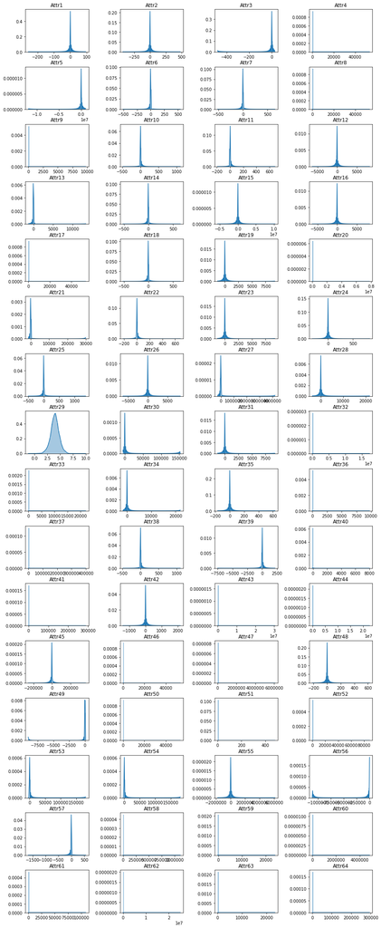

```python
ncol=4
nrow = math.ceil(float(len(ind_columns)/ncol))
fig,ax=plt.subplots(ncols=ncol,nrows=nrow,figsize=(15,40))
plt.style.use('seaborn-bright')
plt.subplots_adjust(wspace=0.5,hspace=0.35)
for i,attr in enumerate(ind_columns):
    row = math.floor(i/ncol)
    col = i%ncol
    g = snb.distplot(train_data[attr].dropna(),ax=ax[row,col],)
    ax[row,col].set_title(attr)
    ax[row,col].set_xlabel("")
plt.show()
fig.clf()
```

**Boxplots for the independent variables**

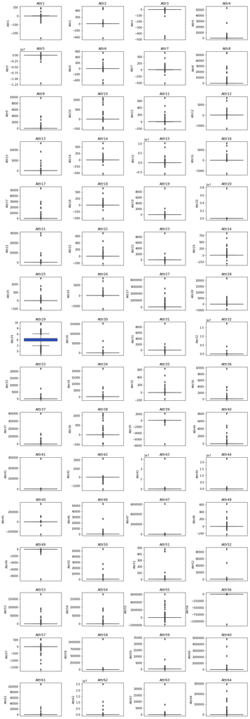

```python
ncol=4
nrow = math.ceil(float(len(ind_columns)/ncol))
fig,ax=plt.subplots(ncols=ncol,nrows=nrow,figsize=(15,48))
plt.subplots_adjust(wspace=0.5,hspace=0.35)
for i,attr in enumerate(ind_columns):
    row = math.floor(i/ncol)
    col = i%ncol
    g = snb.boxplot(y = train_data[attr].dropna(),ax=ax[row,col],)
    ax[row,col].set_title(attr)
    ax[row,col].set_xlabel("")
plt.show()
fig.clf()
```

## Bivariate Analysis

**Check the box plots for the different variables with respect to the classes in the target variable**

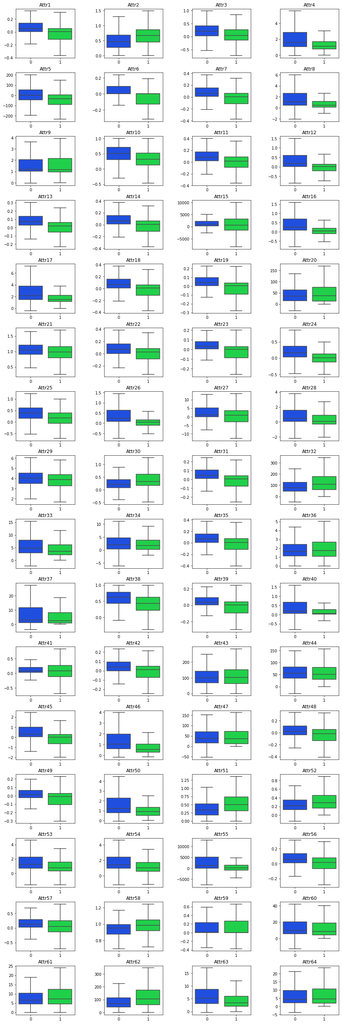

```python
ncol=4
nrow = math.ceil(float(len(ind_columns)/ncol))
fig,ax=plt.subplots(ncols=ncol,nrows=nrow,figsize=(15,48))
plt.subplots_adjust(wspace=0.5,hspace=0.3)
for i,attr in enumerate(ind_columns):
    row = math.floor(i/ncol)
    col = i%ncol
    g = snb.boxplot(y=attr,x="target",data=train_data,ax=ax[row,col],showfliers=False)
    ax[row,col].set_title(attr)
    ax[row,col].set_xlabel("")
    ax[row,col].set_ylabel("")
    ax[row,col].set_xticklabels(["0","1"])
plt.show()
fig.clf()
```

**Check for the multicollinearity**

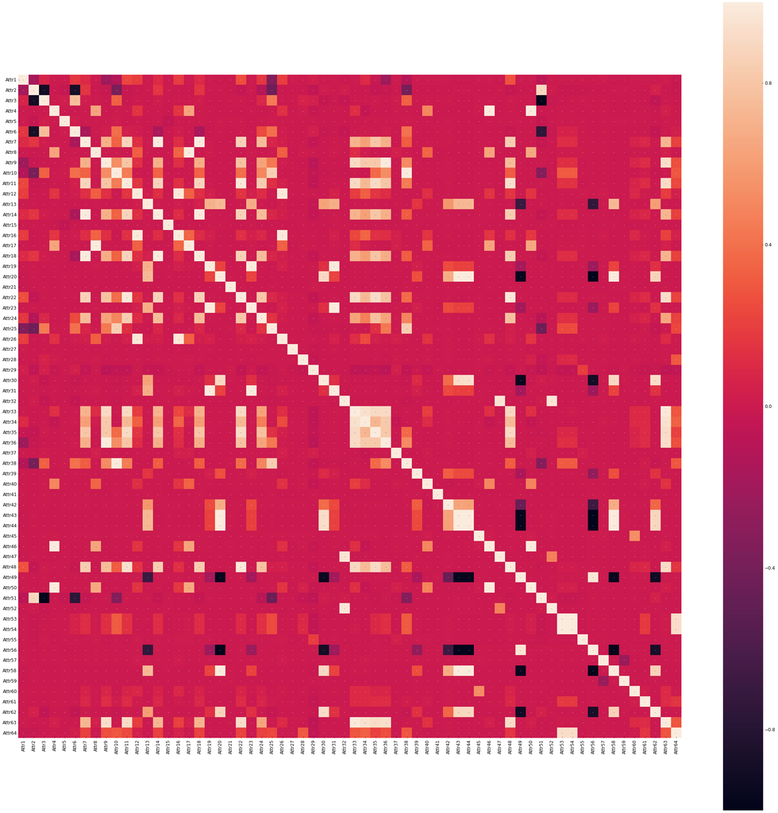

```python
fig = plt.figure(figsize=(40,40))
corrmat = train_data.loc[:,ind_columns].corr()
plt.style.use('classic')
snb.heatmap(corrmat,vmax=1,cbar=True, annot=True, square=True, fmt='.2f', annot_kws={'size': 2})
plt.show()
fig.clf()
```

```python
for i,j in zip(range(64),range(64)):
    if i == j:
        corrmat.iloc[i,j] = 0

pos_corr = corrmat[corrmat > 0.8].fillna(0)
sparse_corrmat = sc.sparse.csc_matrix(pos_corr)
print("Total number of pairs with high positive multi-collinearity",np.count_nonzero(pos_corr),"\n")
print(sparse_corrmat)
```

```
Total number of pairs with high positive multi-collinearity 154

  (50, 1)	0.898333175209
  (45, 3)	0.999924695743
  (49, 3)	0.997877101892
  (10, 6)	0.882788534634
  (13, 6)	0.999999974845
  (17, 6)	0.994750748544
  (21, 6)	0.865407691352
  (34, 6)	0.800063561339
  (47, 6)	0.837536829391
  (16, 7)	0.999537803161
  (32, 8)	0.90681494592
  (33, 8)	0.827488294859
  (34, 8)	0.815578248519
  (35, 8)	0.997562919394
  (62, 8)	0.934035290556
  (24, 9)	0.844751633758
  (37, 9)	0.998820192163
  (6, 10)	0.882788534634
  (13, 10)	0.882788484595
  (17, 10)	0.878141606313
  (21, 10)	0.979343641187
  (23, 10)	0.842019313315
  (32, 10)	0.899963941001
  (34, 10)	0.907494235237
  (47, 10)	0.94456112824
  :	:
  (53, 52)	0.999261882414
  (63, 52)	0.926796631646
  (52, 53)	0.999261882414
  (63, 53)	0.927433970713
  (48, 55)	0.965370310085
  (19, 57)	0.999901618654
  (29, 57)	0.903438471451
  (42, 57)	0.997477312325
  (43, 57)	0.995482772062
  (61, 57)	0.866906919986
  (19, 61)	0.867414417414
  (29, 61)	0.926913708851
  (42, 61)	0.889117999559
  (43, 61)	0.895554873524
  (57, 61)	0.866906919986
  (8, 62)	0.934035290556
  (10, 62)	0.921347135992
  (21, 62)	0.922902915384
  (32, 62)	0.984720279986
  (33, 62)	0.950166422119
  (34, 62)	0.921873692568
  (35, 62)	0.931206135715
  (47, 62)	0.915849822117
  (52, 63)	0.926796631646
  (53, 63)	0.927433970713
```

```python
neg_corr = corrmat[corrmat < -0.8].fillna(0)
sparse_corrmat = sc.sparse.csc_matrix(neg_corr)
print("Total number of pairs with high negative multi-collinearity",np.count_nonzero(neg_corr),"\n")
print(sparse_corrmat)
```

```
Total number of pairs with high negative multi-collinearity 30

  (2, 1)	-0.898900282891
  (5, 1)	-0.882093181559
  (1, 2)	-0.898900282891
  (50, 2)	-0.99780690911
  (1, 5)	-0.882093181559
  (48, 19)	-0.965698877515
  (55, 19)	-0.999887415698
  (48, 29)	-0.954407355658
  (55, 29)	-0.903871497252
  (48, 42)	-0.975935971091
  (55, 42)	-0.997479602489
  (48, 43)	-0.978324829983
  (55, 43)	-0.995490737112
  (19, 48)	-0.965698877515
  (29, 48)	-0.954407355658
  (42, 48)	-0.975935971091
  (43, 48)	-0.978324829983
  (57, 48)	-0.96495921853
  (61, 48)	-0.915149977085
  (2, 50)	-0.99780690911
  (19, 55)	-0.999887415698
  (29, 55)	-0.903871497252
  (42, 55)	-0.997479602489
  (43, 55)	-0.995490737112
  (57, 55)	-0.999976625014
  (61, 55)	-0.867167309218
  (48, 57)	-0.96495921853
  (55, 57)	-0.999976625014
  (48, 61)	-0.915149977085
  (55, 61)	-0.867167309218
```

## Missing Values

```python
print("Number of missing values in the train data: ",train_data.isnull().sum().sum())
```

```
Number of missing values in the train data:  35187
```

Columnwise missing values

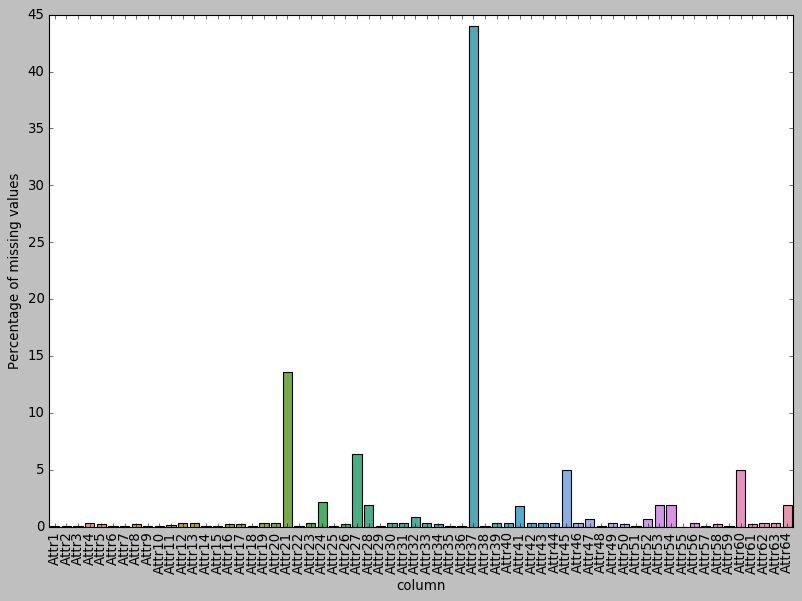

```python
plt.figure(figsize=(12,8))
train_miss = pd.DataFrame({"column":ind_columns,"missing_values":train_data.iloc[:,:64].isnull().sum()/train_data.shape[0]*100})
g_miss = snb.barplot(y="missing_values",x="column",data=train_miss)
g_miss.set_xticklabels(labels=train_miss['column'],rotation=90)
g_miss.set_ylabel("Percentage of missing values")
plt.show()
```

```
    Attr37 has more than 40% of missing values. Check what this column means.
```

```python
features_desc[features_desc["name"]=="Attr37"]
```

|  | name | formula |
| --- | --- | --- |
| 36 | Attr37 | (current assets - inventories) / long-term lia... |

Its ideal to communicate with the data engineer to find out the source of missing values.  
Here, we will simply delete Attr37 and impute other missing values with central imputations that is the mean value.

```python
train_data.drop("Attr37",axis=1,inplace=True)
ind_columns = [i for i in ind_columns if not(i=="Attr37")]
for i,col in enumerate (ind_columns):
    train_data[col].fillna(round(np.mean(train_data[col])),inplace=True)
```

```python
train_data.isnull().sum().sum()
```

```
0
```

Separate independent attributes and target

```python
x = train_data[ind_columns]
y = train_data["target"]
y = ["Bankrupt" if i==1 else "NotBankrupt" for i in y]
```

## Standardization

```python
scl = StandardScaler()
x = scl.fit_transform(x)
```

## Split into train and test data

```python
x_train,x_test,y_train,y_test = train_test_split(x,y,stratify = y,test_size=0.2,random_state=123)
```

```python
np.unique(y_train,return_counts=True)
```

```
(array(['Bankrupt', 'NotBankrupt'],
       dtype='<U11'), array([ 1412, 27830], dtype=int64))
```

```python
np.unique(y_test,return_counts=True)
```

```
(array(['Bankrupt', 'NotBankrupt'],
       dtype='<U11'), array([ 353, 6958], dtype=int64))
```

**Synthetically balance the data using SMOTE**

```python
sampler_SMOTE = SMOTE(random_state=123,ratio={"Bankrupt":10000,"NotBankrupt":27830})
x_SMOTE,y_SMOTE = sampler_SMOTE.fit_sample(x_train,y_train)
```

# Model Building

**Function for printing evaluation metrics**

```python
def error_metrics(pred_test,y_test):
    confusion_df = pd.DataFrame({'actual':y_test,'predicted':pred_test})
    print("Confustion Matrix\n",pd.crosstab(confusion_df['actual'],confusion_df['predicted']),"\n")
    print("Accuracy:",accuracy_score(pred_test,y_test),"\n")
    print("Precision, Recall, F1-score\n",classification_report(y_pred=pred_test,y_true=y_test),"\n")
```

### Logistic Regression

```python
logreg = LogisticRegression()
logreg.fit(x_train,y_train)
pred_test = logreg.predict(x_test)
error_metrics(pred_test,y_test)
```

```
Confustion Matrix
 predicted    Bankrupt  NotBankrupt
actual
Bankrupt           11          342
NotBankrupt       196         6762

Accuracy: 0.926412255505

Precision, Recall, F1-score
              precision    recall  f1-score   support

   Bankrupt       0.05      0.03      0.04       353
NotBankrupt       0.95      0.97      0.96      6958

avg / total       0.91      0.93      0.92      7311
```

Logistic Regression on SMOTE data

```python
logreg.fit(x_SMOTE,y_SMOTE)
pred_test = logreg.predict(x_test)
error_metrics(pred_test,y_test)
```

```
Confustion Matrix
 predicted    Bankrupt  NotBankrupt
actual
Bankrupt           31          322
NotBankrupt       267         6691

Accuracy: 0.9194364656

Precision, Recall, F1-score
              precision    recall  f1-score   support

   Bankrupt       0.10      0.09      0.10       353
NotBankrupt       0.95      0.96      0.96      6958

avg / total       0.91      0.92      0.92      7311
```

## Decision Trees

```python
dtreeclf = DecisionTreeClassifier(random_state=123)
dtreeclf.fit(x_train,y_train)
pred_test = dtreeclf.predict(x_test)
error_metrics(pred_test,y_test)
```

```
Confustion Matrix
 predicted    Bankrupt  NotBankrupt
actual
Bankrupt          189          164
NotBankrupt       206         6752

Accuracy: 0.949391328136

Precision, Recall, F1-score
              precision    recall  f1-score   support

   Bankrupt       0.48      0.54      0.51       353
NotBankrupt       0.98      0.97      0.97      6958

avg / total       0.95      0.95      0.95      7311
```

## Random Forests

```python
RFclf = RandomForestClassifier()

## Define scoring metric
scorer = make_scorer(recall_score,average="weighted",greater_is_better=True,pos_class="Bankrupt")

## Define the Grid
param_grid_comp = {"max_depth":[7,9,12,15],
                   "max_features":[7,9,11,13],
                  "n_estimators":[1000],
                  "min_samples_split":[20]}

model = GridSearchCV(estimator=RFclf,cv=5,param_grid=param_grid_comp,refit=True,n_jobs=-1,iid=True,verbose=1)

model.fit(x_train,y_train)

print("best score: %0.3f",model.best_score_)
print("best parameter set:")
best_estimator = model.best_estimator_
print("\t %s",best_estimator)
```

[output not shown]

[output not shown]

[output not shown]

```python
pred_test=model.predict(np.array(x_test))
error_metrics(pred_test,y_test)
```

```
Confustion Matrix
 predicted    Bankrupt  NotBankrupt
actual
Bankrupt           89          264
NotBankrupt         0         6958

Accuracy: 0.963890028724

Precision, Recall, F1-score
              precision    recall  f1-score   support

   Bankrupt       1.00      0.25      0.40       353
NotBankrupt       0.96      1.00      0.98      6958

avg / total       0.97      0.96      0.95      7311
```

## XGBoost

```python
## Classifier
xgb_clf = xgboost.XGBClassifier(random_state=123)

## Define the grid
param_grid_comp = {"max_depth":[7,9,12],
                   "n_estimators":[50,100,150],
                   "learning_rate":[0.01],
                   "gamma":[1],
                  "subsample":[0.9],
                   "colsample_bytree":[0.75]
                  }

model = GridSearchCV(cv=5,estimator=xgb_clf,param_grid=param_grid_comp,verbose=1,n_jobs=-1,refit=True)

model.fit(x_train,y_train)

print("best score: %0.3f",model.best_score_)
print("best parameter set:")
best_parameters = model.best_estimator_.get_params()
best_estimator = model.best_estimator_
print("\t %s",best_estimator)
```

```
Fitting 5 folds for each of 9 candidates, totalling 45 fits
```

```
[Parallel(n_jobs=-1)]: Done  45 out of  45 | elapsed:  8.3min finished
```

```
best score: %0.3f 0.970829628616
best parameter set:
	 %s XGBClassifier(base_score=0.5, booster='gbtree', colsample_bylevel=1,
       colsample_bytree=0.75, gamma=1, learning_rate=0.01,
       max_delta_step=0, max_depth=12, min_child_weight=1, missing=None,
       n_estimators=150, n_jobs=1, nthread=None,
       objective='binary:logistic', random_state=123, reg_alpha=0,
       reg_lambda=1, scale_pos_weight=1, seed=None, silent=True,
       subsample=0.9)
```

```python
pred_test=model.predict(x_test)
error_metrics(pred_test,y_test)
```

```
Confustion Matrix
 predicted    Bankrupt  NotBankrupt
actual
Bankrupt          147          206
NotBankrupt         7         6951

Accuracy: 0.970865818629

Precision, Recall, F1-score
              precision    recall  f1-score   support

   Bankrupt       0.95      0.42      0.58       353
NotBankrupt       0.97      1.00      0.98      6958

avg / total       0.97      0.97      0.97      7311
```

## Artificial Neural Networks

**Prepare the target for ANN**

```python
lbl_enc = LabelEncoder()
y_train_ANN = to_categorical(lbl_enc.fit_transform(y_train))
y_test_ANN = to_categorical(lbl_enc.fit_transform(y_test))
```

**Define Custom funciton for recall**

```python
def recall(y_true,y_pred):
    TP = K.sum(K.round(K.clip(y_true*y_pred,0,1)))
    AP = K.sum(K.round(K.clip(y_true,0,1)))
    recall = TP / (AP + K.epsilon())
    return recall
```

```python
input_dim = x_train.shape[1]
model = Sequential()

model.add(Dense(50, input_dim=input_dim, activation='relu'))
model.add(BatchNormalization())

model.add(Dense(100,activation='relu'))
model.add(Dropout(0.2))
model.add(BatchNormalization())

model.add(Dense(2))
model.add(Activation('softmax'))
```

```python
model.compile(loss="categorical_crossentropy",optimizer="adam",metrics=["accuracy",recall])
```

```python
model.fit(np.array(x_train),y_train_ANN,epochs=200,shuffle=True,batch_size=64)
```

```
<keras.callbacks.History at 0x2869167ef28>
```

```python
model.evaluate(np.array(x_test),y_test_ANN)
```

```
[0.19158859237735029, 0.95185337163178774, 0.95185337163178774]
```

```python
pred_test = model.predict_classes(np.array(x_test))
pred_test = [np.unique(y_test)[i] for i in pred_test]
error_metrics(pred_test,y_test)
```

```
Confustion Matrix
 predicted    Bankrupt  NotBankrupt
actual
Bankrupt            1          352
NotBankrupt         0         6958

Accuracy: 0.951853371632

Precision, Recall, F1-score
              precision    recall  f1-score   support

   Bankrupt       1.00      0.00      0.01       353
NotBankrupt       0.95      1.00      0.98      6958

avg / total       0.95      0.95      0.93      7311
```

**ANN is not performing well on the original imbalanced data**  
**Lets fit it on synthetically balanced data**

prepare the target

```python
y_trainSMOTE_ANN = to_categorical(lbl_enc.fit_transform(y_SMOTE))
```

```python
model.compile(loss="categorical_crossentropy",optimizer="adam",metrics=["accuracy"])
model.fit(np.array(x_SMOTE),y_trainSMOTE_ANN,epochs=100,shuffle=True,batch_size=64)
```

```
<keras.callbacks.History at 0x286a141cc50>
```

```python
model.evaluate(np.array(x_test),y_test_ANN)
```

```
[0.57218990843137241, 0.94939132813568594]
```

```python
pred_test = model.predict_classes(np.array(x_test))
pred_test = [np.unique(y_test)[i] for i in pred_test]
error_metrics(pred_test,y_test)
```

```
Confustion Matrix
 predicted    Bankrupt  NotBankrupt
actual
Bankrupt            5          348
NotBankrupt        22         6936

Accuracy: 0.949391328136

Precision, Recall, F1-score
              precision    recall  f1-score   support

   Bankrupt       0.19      0.01      0.03       353
NotBankrupt       0.95      1.00      0.97      6958

avg / total       0.92      0.95      0.93      7311
```